# FB1/FB2 trajectories

RA ([numpde](https://github.com/numpde/))

2021-04-28

## Preliminaries

### Introduction

[tradeSeq](http://bioconductor.org/packages/release/bioc/vignettes/tradeSeq/inst/doc/tradeSeq.html)

### Setup

```r
suppressPackageStartupMessages({
  # install.packages("kableExtra")
  requireNamespace("kableExtra")

  # install.packages("crunch")
  requireNamespace("crunch")

  # https://rstudio.github.io/DT/
  # install.packages("DT")
  requireNamespace("DT")

  # may need to say "don't restart session"
  # install.packages("RCurl")
  requireNamespace("RCurl")

  # install.packages("dplyr")
  library(dplyr)
  # install.packages("ggplot2")
  library(ggplot2)

  #
  requireNamespace("magrittr")
  `%<>%` <- magrittr::`%<>%`
  `%>%` <- magrittr::`%>%`

  #
  requireNamespace("tidyr")

  # BiocManager::install("org.Mm.eg.db")
  requireNamespace("org.Mm.eg.db")

  # https://www.bioconductor.org/packages/release/bioc/vignettes/goseq/inst/doc/goseq.pdf
  # BiocManager::install("goseq")
  requireNamespace("goseq")

  # https://vroom.r-lib.org/articles/vroom.html
  # install.packages("vroom")
  requireNamespace("vroom")

  # BiocManager::install("DESeq2")
  requireNamespace("DESeq2")

  # BiocManager::install("scater")
  requireNamespace("scater")

  # BiocManager::install("scran")
  requireNamespace("scran")

  # BiocManager::install("igraph")
  requireNamespace("igraph")

  # install.packages("pheatmap")
  requireNamespace("pheatmap")
  # install.packages("stringr")
  requireNamespace("stringr")
  # install.packages("reshape2")
  requireNamespace("reshape2")
  # install.packages("pathlibr")
  requireNamespace("pathlibr")
  # install.packages("pbapply")
  requireNamespace("pbapply")

  # install.packages("Rtsne")
  requireNamespace("Rtsne")
  # install.packages("uwot")
  requireNamespace("uwot")

  # avoid importing `exprs` that leads to clashes
  requireNamespace("rlang")

  # install.packages("Seurat")
  requireNamespace("Seurat")

  # BiocManager::install("TrajectoryUtils") # Didn't work
  # devtools::install_github("LTLA/TrajectoryUtils@e943606")
  # BiocManager::install("kstreet13/slingshot@25fc566")
  requireNamespace("slingshot")

  # BiocManager::install("tradeSeq")
  requireNamespace("tradeSeq")

  # Monocle3
  # https://cole-trapnell-lab.github.io/monocle3/docs/installation/
  # BiocManager::install(c("BiocGenerics", "DelayedArray", "DelayedMatrixStats", "limma", "S4Vectors", "SingleCellExperiment", "SummarizedExperiment", "batchelor", "Matrix.utils"))
  # install.packages("devtools")
  # devtools::install_github("cole-trapnell-lab/leidenbase@8c52ebc")
  # apt install libudunits2-dev libgdal-dev libgeos-dev libproj-dev
  # devtools::install_github("cole-trapnell-lab/monocle3@4c01d89")
  # requireNamespace("monocle3") #
})
```

[output not shown]

[output not shown]

[output not shown]

[output not shown]

[output not shown]

[output not shown]

[output not shown]

[output not shown]

[output not shown]

[output not shown]

[output not shown]

[output not shown]

[output not shown]

[output not shown]

[output not shown]

[output not shown]

[output not shown]

[output not shown]

[output not shown]

[output not shown]

[output not shown]

[output not shown]

[output not shown]

[output not shown]

[output not shown]

[output not shown]

[output not shown]

[output not shown]

[output not shown]

[output not shown]

[output not shown]

[output not shown]

[output not shown]

[output not shown]

[output not shown]

[output not shown]

[output not shown]

[output not shown]

[output not shown]

[output not shown]

[output not shown]

[output not shown]

[output not shown]

[output not shown]

[output not shown]

[output not shown]

[output not shown]

[output not shown]

[output not shown]

[output not shown]

[output not shown]

[output not shown]

[output not shown]

[output not shown]

[output not shown]

[output not shown]

[output not shown]

[output not shown]

[output not shown]

[output not shown]

[output not shown]

[output not shown]

[output not shown]

[output not shown]

[output not shown]

[output not shown]

[output not shown]

[output not shown]

[output not shown]

[output not shown]

[output not shown]

[output not shown]

[output not shown]

[output not shown]

[output not shown]

[output not shown]

[output not shown]

[output not shown]

[output not shown]

[output not shown]

[output not shown]

[output not shown]

[output not shown]

[output not shown]

[output not shown]

[output not shown]

[output not shown]

[output not shown]

[output not shown]

[output not shown]

[output not shown]

[output not shown]

[output not shown]

[output not shown]

[output not shown]

[output not shown]

[output not shown]

[output not shown]

[output not shown]

[output not shown]

[output not shown]

[output not shown]

[output not shown]

[output not shown]

[output not shown]

### PRG

```r
set.seed(42)
```

### Paths

```r
BASEPATH <- pathlibr::Path$new(".")
stopifnot("main.Rmd" %in% names(BASEPATH$dir))
```

```r
path_to <- (function(.) Sys.glob(BASEPATH$join("../..")$join(.)$show))
```

```r
out_file <- (function(.) BASEPATH$join("output")$join(.)$show)
dir.create(out_file(""), showWarnings = FALSE)
```

### Plotting

```r
ggplot2::theme_set(theme_light(base_size = 15))
```

```r
kable <- function(.) {
  kableExtra::kbl(., align = "c") %>%
    kableExtra::kable_paper("hover", full_width = F)
}
```

```r
options(DT.options = list(
  pageLength = 16,
  language = list(search = "Filter:")
))
```

```r
as.link <-
  function(x) {
    dplyr::case_when(
      # If x is like GO:003453
      startsWith(x, "GO:") ~ paste0(
        "<a target='_blank'",
        "href='", "http://amigo.geneontology.org/amigo/term/", x, "'",
        ">", x, "</a>"
      ),
      # Otherwise try this
      TRUE ~ paste0(
        "<a target='_blank'",
        "href='", "http://www.informatics.jax.org/marker/summary?nomen=", x, "'",
        ">", x, "</a>"
      )
    )
  }
```

```r
show_de_table <- function(.) {
  (.) %>%
    select(base = baseMean, l2fc = log2FoldChange, p = pvalue, padj) %>%
    ind2col("symbol") %>%
    mutate(symbol = as.link(symbol)) %>%
    DT::datatable(escape = FALSE) %>%
    DT::formatSignif(c("base", "l2fc", "p", "padj"), digits = 3)
}
```

```r
show_go_table <- function(.) {
  (.) %>%
    dplyr::select("category", "overrep.p", "#DE", "#cat", "term", "GO") %>%
    DT::datatable(escape = FALSE) %>%
    DT::formatSignif("overrep.p", digits = 3)
}
```

### Dataframes

```r
# Use first column as index
by_col1 <- (function(.) tibble::column_to_rownames(., colnames(.)[1]))
# Use index as new column `name`
ind2col <- (function(., name) tibble::rownames_to_column(., var = name))
```

```r
arrange.like <- (function(X, T) X[rownames(T), , drop = FALSE])
rows.of <- (function(rows, X) X[rows, , drop = FALSE])
```

```r
Sys.setenv("VROOM_CONNECTION_SIZE" = 131072 * 4)
from_csv <- function(.) {
  vroom::vroom(., del = "\t", progress = FALSE) %>%
    by_col1() %>%
    suppressMessages()
}
```

A call to `to_csv` should be preceded by `ind2col("name for index")` to write the row names.

```r
to_csv <- function(., f) {
  vroom::vroom_write(., out_file(f), delim = "\t")
}
```

The following function constructs a `SingleCellExperiment`, while checking consistency of sample names.

```r
make_sce <- function(counts, coldata) {
  # Check that samples in counts = genes x samples
  # are ordered as in coldata = samples x metafields
  stopifnot(assertthat::are_equal(colnames(counts), rownames(coldata)))
  SingleCellExperiment::SingleCellExperiment(
    assays = list(counts = counts), colData = coldata
  )
}
```

### Misc

–

## Datasets

### Betsholtz, 2018

#### About

GSE98816: single cell RNA-seq of mouse brain vascular transcriptomes.

#### Load

```r
sce_bth_mb <-
  make_sce(
      counts = (
        path_to("*/Betsholtz-2018/*/expr.csv.gz") %>%
          from_csv() %>%
          t()
      ),
      coldata = (
        path_to("*/Betsholtz-2018/*/meta.csv.gz") %>%
          from_csv()
      )
  ) %>%
  # Only keep FB
  `[`(, (.)$celltype %in% c("FB1", "FB2")) %>%
  # Order by cell type
  `[`(, order((.)$celltype))

# conversion to matrix takes long, hence do it here
sce_bth_mb@assays@data$counts %<>% as.matrix()
```

#### Diagnostics

Attach diagnostics by scater.

```r
sce_bth_mb %<>% (function(sce) {
  scater::addPerCellQC(
    x = sce,
    subsets = list(Mito = grep("mt-", rownames(sce)))
  ) %>%
    # Used for the heatmap
    scater::logNormCounts() %>%
    # Not all are used further below:
    scater::runPCA(name = "PCA", ncomponents = 20) %>%
    scater::runTSNE(perplexity = 10, dimred = "PCA") %>%
    scater::runUMAP()
})
```

Projections:

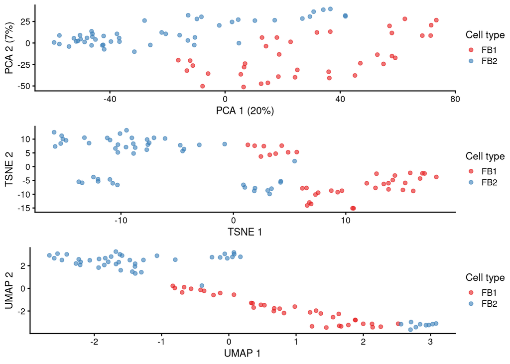

```r
sce_bth_mb %>%
  {
    function(which_dimred) {
      scater::plotReducedDim(
        dimred = which_dimred,
        object = (.),
        colour_by = "celltype"
      ) +
        scale_color_brewer(palette = "Set1", name = "Cell type")
    }
  } %>%
  {
    gridExtra::grid.arrange((.)("PCA"), (.)("TSNE"), (.)("UMAP"), nrow = 3)
  }
```

### AB – Mouse ctx & hip (10x)

#### About

“Mouse Whole Cortex and Hippocampus 10x” dataset from Allen Brain, 2020: [[explore](https://celltypes.brain-map.org/rnaseq/mouse_ctx-hip_10x)], [[download](https://portal.brain-map.org/atlases-and-data/rnaseq/mouse-whole-cortex-and-hippocampus-10x)], [[protocols](https://portal.brain-map.org/atlases-and-data/rnaseq/protocols-mouse-cortex-and-hippocampus)].

#### Diagnostics

Attach diagnostics by scater.

```r
sce_abm_ch %<>% (function(sce) {
  scater::addPerCellQC(
    x = sce,
    subsets = list(Mito = grep("mt-", rownames(sce)))
  ) %>%
    # Used for the heatmap
    scater::logNormCounts() %>%
    # Not all are used further below:
    scater::runPCA(name = "PCA", ncomponents = 20) %>%
    scater::runTSNE(perplexity = 10, dimred = "PCA") %>%
    scater::runUMAP()
})
```

Projections:

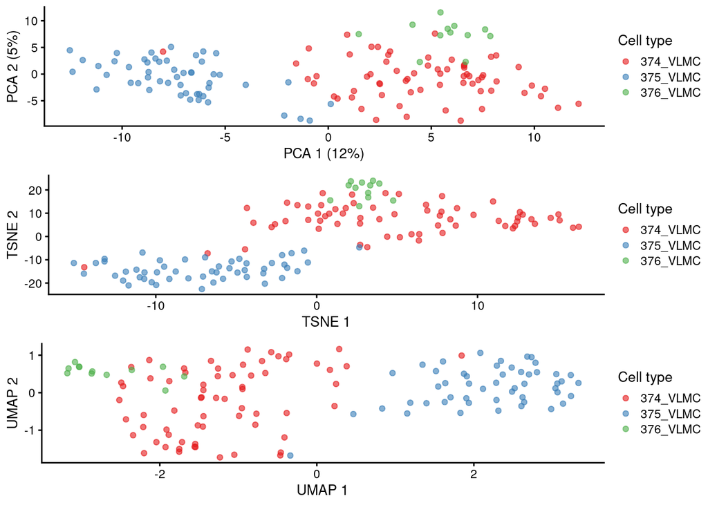

```r
sce_abm_ch %>%
  {
    function(which_dimred) {
      scater::plotReducedDim(
        dimred = which_dimred,
        object = (.),
        colour_by = "cell_type_alias_label"
      ) +
        scale_color_brewer(palette = "Set1", name = "Cell type")
    }
  } %>%
  {
    gridExtra::grid.arrange((.)("PCA"), (.)("TSNE"), (.)("UMAP"), nrow = 3)
  }
```

## Analysis

### Slingshot pseudotime

Compute trajectory / pseudotime.

```r
sce_bth_mb.slingshot <-
  sce_bth_mb %>%
  slingshot::slingshot(
    reducedDim = "PCA",
    clusterLabels = "celltype",
    # If we do not provide the start-cluster and end-cluster,
    # slingshot finds the same lineage.
    start.clus = "FB1",
    end.clus = "FB2"
  ) %>%
  # This is of class PseudotimeOrdering, which
  # looks like the original SCE but DESeq2 doesn't like it.
  # So, we downgrade to avoid confusion:
  slingshot::SlingshotDataSet()
```

```r
sce_bth_mb.slingshot %>%
  slingshot::slingLineages() %>%
  as.data.frame() %>%
  kable()
```

| Lineage1 |
| --- |
| FB1 |
| FB2 |

Attach the pseudotime. Accessible using `...$Lineage1`.

```r
sce_bth_mb@colData %<>%
  cbind(sce_bth_mb.slingshot %>% slingshot::slingPseudotime())
```

Save the lineage/s to disk.

```r
sce_bth_mb.slingshot %>%
  slingshot::slingPseudotime() %>%
  as.data.frame %>%
  ind2col("sample") %>%
  to_csv("pseudotime.csv")
```

Show in plot.

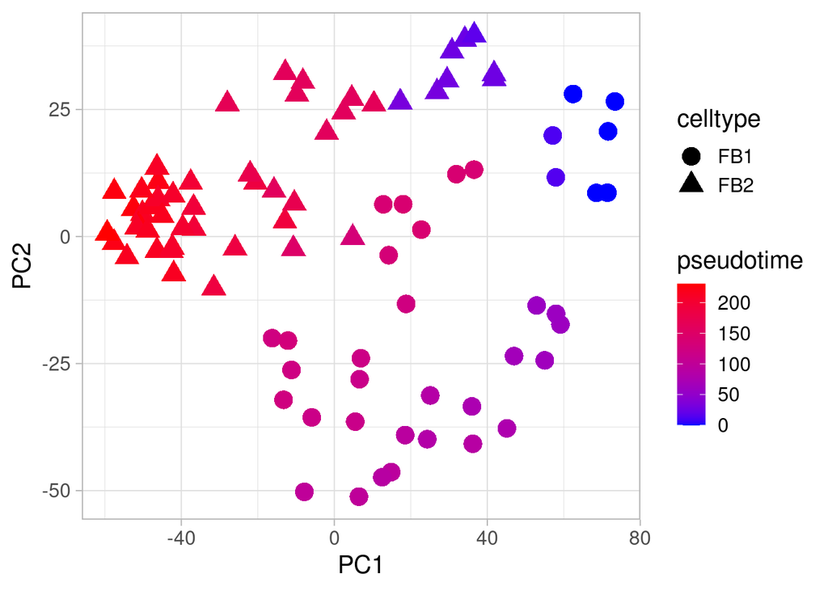

```r
sce_bth_mb %>%
  {
    cbind(
      SingleCellExperiment::reducedDim(., type = "PCA"),
      data.frame(
        pseudotime = (.)$Lineage1,
        celltype = (.)$celltype
      )
    )
  } %>%
  as.data.frame() %>%
  ggplot(aes(x = PC1, y = PC2, color = pseudotime, shape = celltype)) +
  geom_point(size = 5) +
  ggplot2::scale_color_gradient(low = "Blue", high = "Red")
```

### Early vs late

We partition the samples into “early” (first quarter) and “late” (last quarter) in terms of pseudotime, and find DE genes between those two groups. These DE genes will narrow down the search of the “association test” below.

```r
sce_bth_mb %<>%
  (function(sce) {
    sce$Lineage1 %>%
      list(
        is_early = ((.) < quantile((.), p = c(0.25))),
        is_late = ((.) >= quantile((.), p = c(0.75)))
      ) %>%
      with({
        sce$early <- as.factor(is_early)
        sce$late <- as.factor(is_late)

        sce
      })
  })
```

Overview.

```r
sce_bth_mb$celltype %>%
  unique() %>%
  sort() %>%
  sapply(function(ct) {
    sce_bth_mb %>% {
      ii <- ((.)$celltype == ct)
      c(
        early = sum((.)$early[ii] == TRUE),
        neither = sum(((.)$early[ii] == FALSE) & ((.)$late[ii] == FALSE)),
        late = sum((.)$late[ii] == TRUE)
      )
    }
  }) %>%
  kable()
```

|  | FB1 | FB2 |
| --- | --- | --- |
| early | 14 | 8 |
| neither | 23 | 19 |
| late | 0 | 22 |

Find DE genes between “early” and “late”.

```r
de_results.late_vs_early <-
  sce_bth_mb %>%
  # Only keep the early and the late
  `[`(, ((.)$early == TRUE) | ((.)$late == TRUE)) %>%
  {
    (.) %>%
      DESeq2::DESeqDataSet(design = ~early) %>%
      DESeq2::estimateSizeFactors() %>%
      DESeq2::DESeq(quiet = TRUE, fitType = "local") %>%
      DESeq2::results()
  } %>%
  as.data.frame() %>%
  slice_min(pvalue, n = 777)
```

```r
de_results.late_vs_early %>%
  show_de_table()
```

|  | symbol | base | l2fc | p | padj |
| --- | --- | --- | --- | --- | --- |
| 1 | Ptgs2 | 69.0061883101334 | -25.2242389521496 | 5.03858763194757e-58 | 3.67665739503214e-54 |
| 2 | Cxcl10 | 122.801810494919 | -24.6578675138551 | 1.14711387298037e-49 | 4.1852449655689e-46 |
| 3 | Slc13a4 | 19.4070040127334 | 25.2415100809299 | 4.84819887406799e-47 | 1.17924357280247e-43 |
| 4 | Lars2 | 2387.82490460854 | 5.38970643558993 | 4.83683084691308e-42 | 8.82358867248118e-39 |
| 5 | Dcdc2a | 40.6554929506018 | 26.2717885981022 | 6.6987555030032e-39 | 9.77616378108287e-36 |
| 6 | Ndfip1 | 41.786737124754 | -7.72752518689328 | 1.81623357897759e-38 | 2.20884273763325e-35 |
| 7 | Trim32 | 17.1194538188882 | -23.6980617050064 | 1.10517103963111e-37 | 1.15206186802688e-34 |
| 8 | Rn45s | 24958.4207374801 | 3.14962352771845 | 1.57295866813546e-36 | 1.43473492517305e-33 |
| 9 | Tusc3 | 30.468347048305 | -7.54881256101868 | 4.02292421533882e-33 | 3.26169755548082e-30 |
| 10 | Tcf21 | 106.241666204556 | -8.65714871378455 | 4.83222988686447e-33 | 3.526078148445e-30 |

[output cut: 767 more lines]

### GO term enrichment

#### Compute

```r
# Number of early/late genes.
n <- 33
```

```r
enriched_go_terms <-
  de_results.late_vs_early %>%
  {
    list(
      up_early = (.) %>% filter(log2FoldChange > 0),
      up_late = (.) %>% filter(log2FoldChange < 0)
    )
  } %>%
  lapply(function(.) {
    (.) %>%
      arrange(pvalue) %>%
      rownames()
  }) %>%
  within({
    f <- (function(x) x[1:5] %>% paste(collapse = ", "))
    print(paste("Up early:", f(up_early), "..."))
    print(paste("Up late: ", f(up_late), "..."))
    rm(f)
  }) %>%
  lapply(function(de_results) {
    de_results %>%
      data.frame(symbol = .) %>%
      slice_head(n = n) %>%
      # Get the Entrez IDs of our genes
      merge(
        org.Mm.eg.db::org.Mm.egSYMBOL2EG %>% as.data.frame(),
        by = "symbol"
      ) %>%
      pull(gene_id) %>%
      # Enrichment analysis
      limma::goana(species = "Mm") %>%
      # Limit selection
      filter(P.DE <= 0.05) %>%
      arrange(P.DE) %>%
      # Format for display
      ind2col("category") %>%
      mutate(category = as.link(category)) %>%
      rename(
        # new name = old name
        "overrep.p" = P.DE, "#DE" = DE, "#cat" = N, "GO" = Ont, "term" = Term
      )
  })
```

```
## [1] "Up early: Slc13a4, Lars2, Dcdc2a, Rn45s, Vtn ..."
## [1] "Up late:  Ptgs2, Cxcl10, Ndfip1, Trim32, Tusc3 ..."
```

#### Early up

GO terms associated with 33 “early” genes.

```r
enriched_go_terms$up_early %>% show_go_table()
```

|  | category | overrep.p | #DE | #cat | term | GO |
| --- | --- | --- | --- | --- | --- | --- |
| 1 | GO:0005343 | 6.04216642243244e-06 | 3 | 28 | organic acid:sodium symporter activity | MF |
| 2 | GO:0022853 | 7.83036060415783e-06 | 5 | 218 | active ion transmembrane transporter activity | MF |
| 3 | GO:0001704 | 8.46616478423107e-06 | 4 | 102 | formation of primary germ layer | BP |
| 4 | GO:0005332 | 9.45145197264303e-06 | 2 | 4 | gamma-aminobutyric acid:sodium symporter activity | MF |
| 5 | GO:0048598 | 1.46262245284889e-05 | 7 | 652 | embryonic morphogenesis | BP |
| 6 | GO:1902338 | 3.3001129727861e-05 | 2 | 7 | negative regulation of apoptotic process involved in morphogenesis | BP |
| 7 | GO:0015185 | 3.3001129727861e-05 | 2 | 7 | gamma-aminobutyric acid transmembrane transporter activity | MF |
| 8 | GO:0007611 | 3.57958880943131e-05 | 5 | 299 | learning or memory | BP |
| 9 | GO:0015081 | 3.76777680874724e-05 | 4 | 149 | sodium ion transmembrane transporter activity | MF |
| 10 | GO:0031012 | 4.0605316307722e-05 | 6 | 513 | extracellular matrix | CC |

[output cut: 778 more lines]

#### Late up

GO terms associated with 33 “late” genes.

```r
enriched_go_terms$up_late %>% show_go_table()
```

|  | category | overrep.p | #DE | #cat | term | GO |
| --- | --- | --- | --- | --- | --- | --- |
| 1 | GO:0006952 | 1.60393331657349e-08 | 14 | 1710 | defense response | BP |
| 2 | GO:0006950 | 1.47420711951427e-06 | 17 | 3745 | response to stress | BP |
| 3 | GO:0009605 | 1.61063143012157e-06 | 15 | 2883 | response to external stimulus | BP |
| 4 | GO:0032101 | 2.60697330900533e-06 | 9 | 919 | regulation of response to external stimulus | BP |
| 5 | GO:0010499 | 3.46145066244499e-06 | 3 | 22 | proteasomal ubiquitin-independent protein catabolic process | BP |
| 6 | GO:0006954 | 4.53751527452107e-06 | 8 | 729 | inflammatory response | BP |
| 7 | GO:0002376 | 7.85529153050058e-06 | 14 | 2832 | immune system process | BP |
| 8 | GO:0050727 | 9.7019384148831e-06 | 6 | 372 | regulation of inflammatory response | BP |
| 9 | GO:0031347 | 1.24437285537894e-05 | 7 | 594 | regulation of defense response | BP |
| 10 | GO:0031348 | 1.33867172562131e-05 | 5 | 228 | negative regulation of defense response | BP |

[output cut: 993 more lines]

### Association test

From [tradeSeq](http://bioconductor.org/packages/release/bioc/vignettes/tradeSeq/inst/doc/tradeSeq.html): `associationTest` is testing the null hypothesis that all smoother coefficients are equal to each other. This can be interpreted as testing whether the average gene expression is significantly changing along pseudotime.

```r
tradeseq.assotest <-
  sce_bth_mb %>%
  # Reduce the geneset for efficiency
  `[`(rownames(de_results.late_vs_early), ) %>%
  {
    tradeSeq::fitGAM(
      (.)@assays@data$counts,
      sds = sce_bth_mb.slingshot,
      parallel = FALSE
    )
  } %>%
  tradeSeq::associationTest()
```

Order cells by pseudotime and genes by log-fold change (indicating early-vs-late). We normalize genewise for better visibilty.

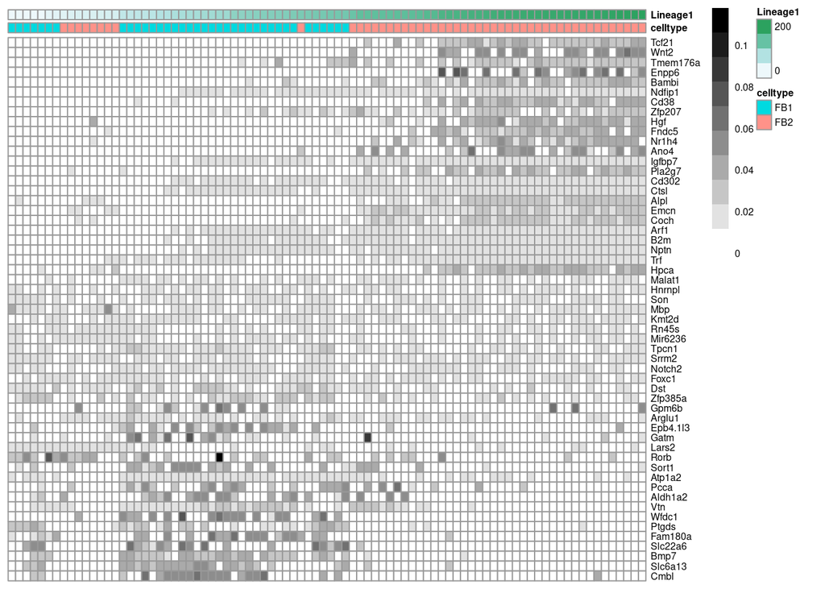

```r
sce_bth_mb %>%
  list(
    sce = .,
    # Order by pseudotime (drop NA's)
    pst = order((.)$Lineage1, na.last = NA),
    # Extract the lineage-associated genes
    top = tradeseq.assotest %>%
      # Some pvalue are zero => the order is not stable? => use waldStat
      slice_max(order_by = waldStat, n = 55) %>%
      rownames() %>%
      # Order by LFC (negative to positive)
      `[`(order(de_results.late_vs_early[(.), ]$log2FoldChange))
  ) %>%
  with({
    # Most-associated genes and order by pseudotime
    sce[top, pst]
  }) %>%
  {
    pheatmap::pheatmap(
      log1p((.)@assays@data$count) %>% {
        (.) / rowSums(.)
      },
      show_colnames = FALSE,
      cluster_cols = FALSE,
      cluster_rows = FALSE,
      treeheight_row = 0,
      treeheight_col = 0,
      fontsize = 6,
      color = grDevices::colorRampPalette(c("white", "black"))(10),
      annotation_col = (
        (.)@colData %>%
          as.data.frame() %>%
          select(celltype, Lineage1)
      )
    )
  }
```

Look at the same genes for VLMC from the AB Mouse WCH dataset.

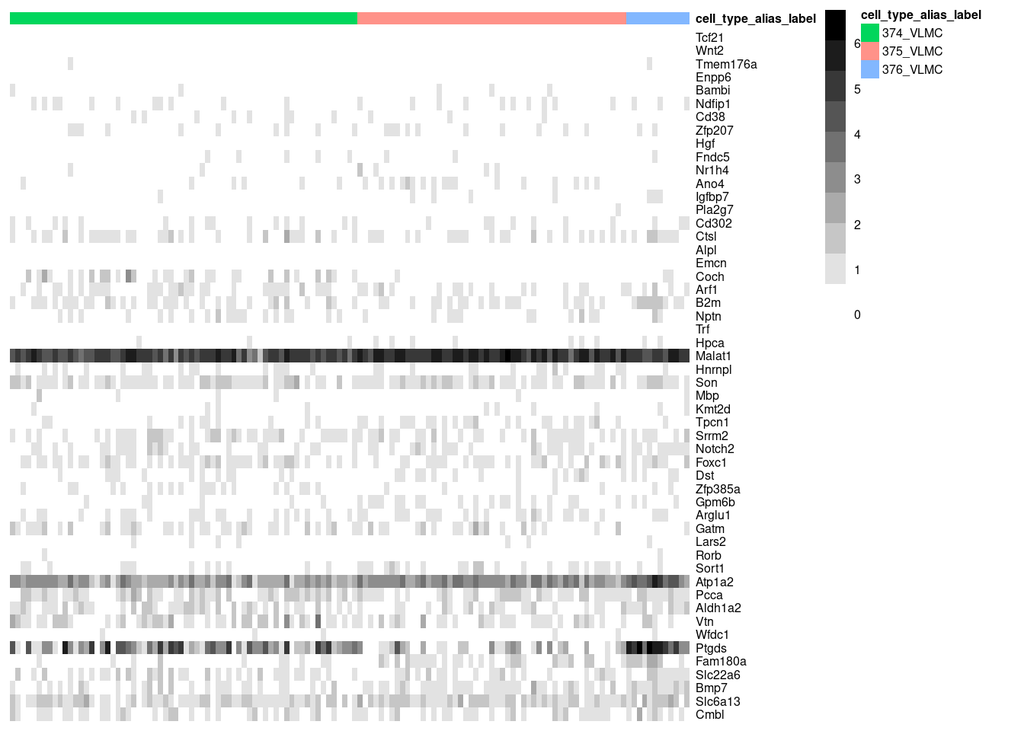

```r
sce_abm_ch %>%
    list(
    sce = .,
    # Extract the same lineage-associated genes
    top = tradeseq.assotest %>%
      slice_max(order_by = waldStat, n = 55) %>%
      rownames() %>%
      `[`(order(de_results.late_vs_early[(.), ]$log2FoldChange))
  ) %>%
  with({
    # Most-associated genes
    sce[top[top %in% rownames(sce)], ]
  }) %>% {
    pheatmap::pheatmap(
      log1p((.)@assays@data$count),
      show_colnames = FALSE,
      cluster_cols = FALSE,
      cluster_rows = FALSE,
      treeheight_row = 0,
      treeheight_col = 0,
      fontsize = 6,
      color = grDevices::colorRampPalette(c("white", "black"))(10),
      annotation_col = (
        (.)@colData %>%
          as.data.frame() %>%
          select(cell_type_alias_label)
      )
    )
  }
```